# Отчёт по лабораторной работе 4

Первоначальное конфигурирование сети

Седохин Даниил Алексеевич

1132231845@pfur.ru

Российский университет дружбы народов

# 1 Цель работы

Провести подготовительную работу по первоначальной настройке коммутаторов сети.

# 2 Задание

В логической рабочей области Packet Tracer разместите коммутаторы и оконечные устройства согласно схеме сети L1 (см. рис. 3.1 из раздела 3.3) и соедините их через соответствующие интерфейсы (рис. 1).

[figure not shown]

Рисунок 1: Размещение коммутаторов и оконечных устройств согласно схеме

Теперь нам необходимо перовести первоначальную настройку коммутаторов нашей сети.

Настроим каждый коммутатор: (рис. 2).

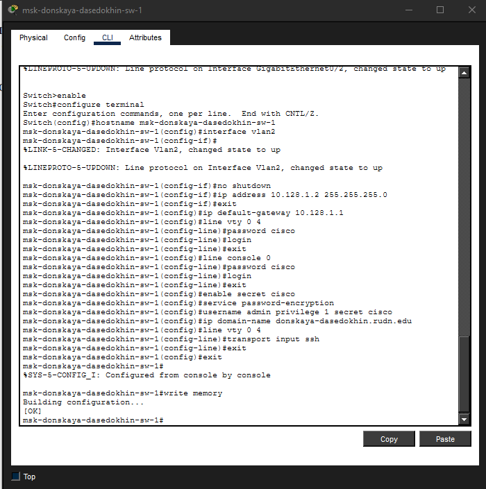

Рисунок 2: Настройка коммутатора msk-donskaya-dasedokhin-sw-1

Настройка коммутатора msk-donskaya-dasedokhin-sw-2 (рис. 3).

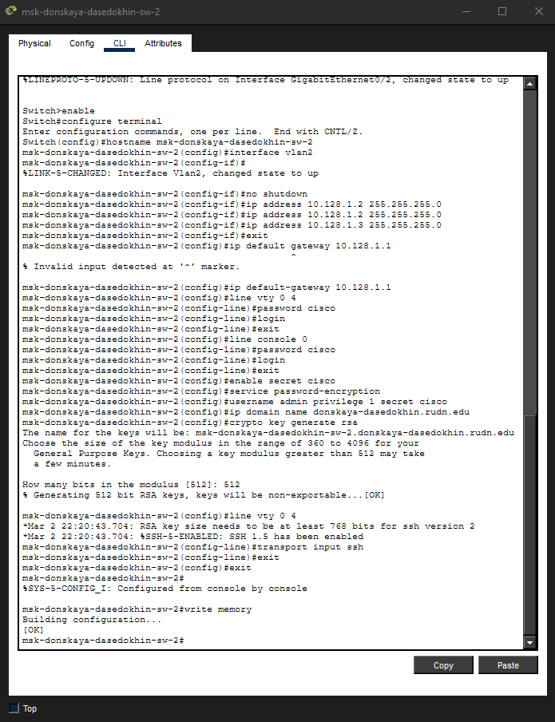

Рисунок 3: Настройка коммутатора msk-donskaya-dasedokhin-sw-2

Настройка коммутатора msk-donskaya-dasedokhin-sw-3 (рис. 4).

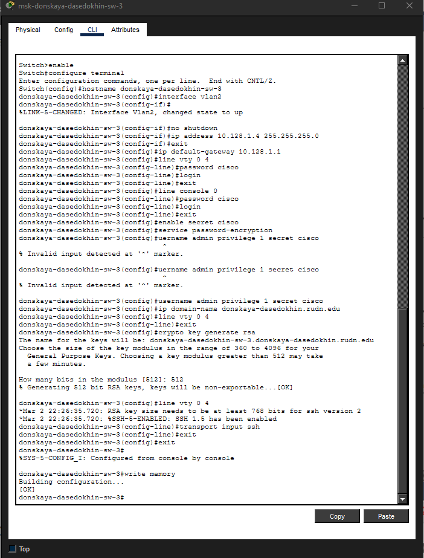

Рисунок 4: Настройка коммутатора msk-donskaya-dasedokhin-sw-3

Настройка коммутатора msk-donskaya-dasedokhin-sw-4 (рис. 5).

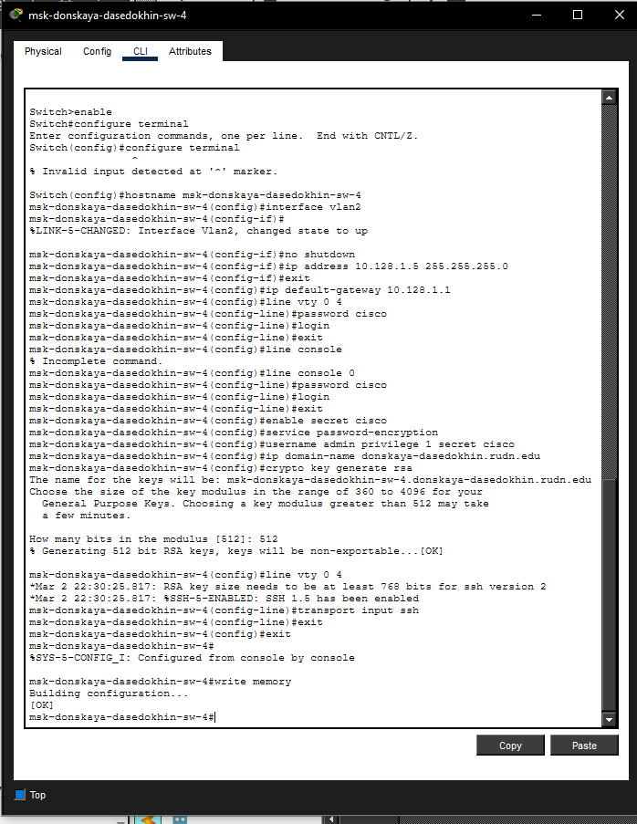

Рисунок 5: Настройка коммутатора msk-donskaya-dasedokhin-sw-4

Настройка коммутатора msk-pavlovskaya-dasedokhin-sw-1 (рис. 6).

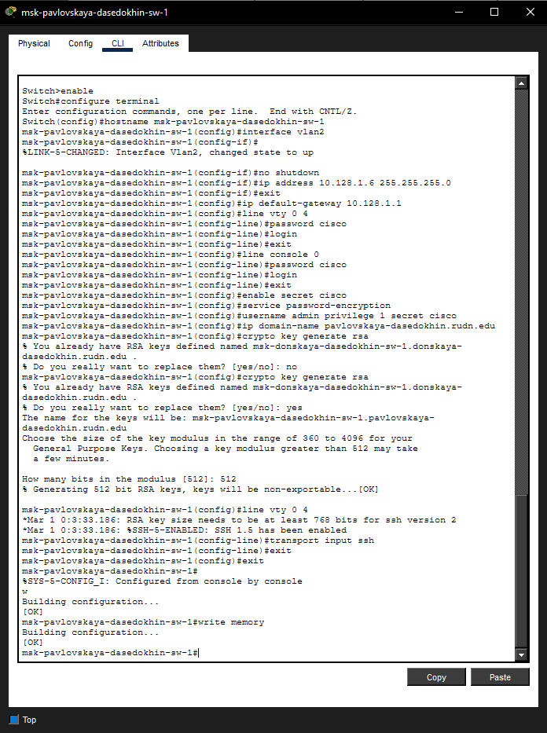

Рисунок 6: Настройка коммутатора msk-pavlovskaya-dasedokhin-sw-1

# 3 Контрольные вопросы

1. При помощи каких команд можно посмотреть конфигурацию сетевого оборудования?

show running-config

2. При помощи каких команд можно посмотреть стартовый конфигурационный файл оборудования?

show startup-config

3. При помощи каких команд можно экспортировать конфигурационный файл оборудования?

copy running-config startup-config write memory

copy running-config tftp:

copy running-config flash:имя_файла.txt

4. При помощи каких команд можно импортировать конфигурационный файл оборудования?

copy tftp: running-config

copy flash:имя_файла.txt running-config

copy startup-config running-config

# 4 Выводы

Я приобрел навыки по первоначальной неастройке коммутатоов сети.